# Datos: Entendimiento y Análisis Exploratorio

```r
t<-Sys.time()
```

```r
source('02_Utils.R')
```

# Entendimiento de los datos.

## Recolección de los datos iniciales

La recolección de los datos iniciales se realiza directamente desde la terminal. Para ello es necesario realizar los siguientes pasos:

1. Asegurarse de que se tiene una versión de python 3 o superior. De no ser así, actualizar python (por ejemplo, se pueden seguir las instrucciones en https://docs.python-guide.org/starting/install3/osx/).
2. Acceder a su cuenta de Kaggle. De no tener una, es necesario registrarse en https://www.kaggle.com/.
3. Una vez que se accedió a la cuenta, ingresar a la sección **“My Account”**

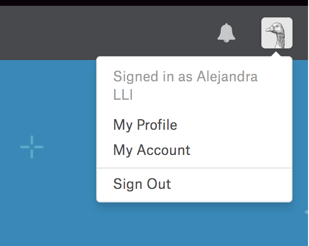

4. Obtener un token en formato .json en la sección **API** seleccionando el boton **“Create New API Token”**. Guardar este token en la carpeta de **“Downloads”** del directorio raíz.

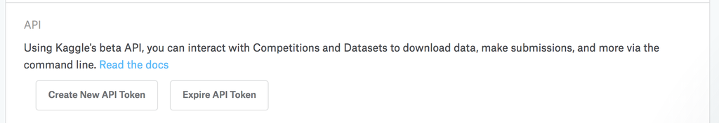

5. Correr el archivo **DescargaDatos.sh** en la terminal. Este archivo:
   1. Installa la API de Kaggle.
   2. Crea el directorio **.kaggle** en la raíz.
   3. Transfiere el token a la carpeta del paso anterior.
   4. Crea la carpeta **Proyecto_Final** en dentro del directorio **Documents**.
   5. Crea las carpetas **Datos**, **Datos_trad** y **Datos_clean** dentro del directorio del proyecto final.
   6. Descarga los datos de la competencia *Predict Future Sales* en la carpeta **Datos**.
   7. Descomprime los archivos con extensión **.gz**

## Exploración de los datos

Para poder realizar una exploración de los datos, primero es necesario convertir los campos en ruso a un idioma que podamos entender. Elegimos la traducción al inglés para tratar de ganar la mayor precisión posible.

### Traducción del ruso al inglés

Para la traducción de los catálogos del ruso al inglés se utilizó la librería translateR de R y la API de Google Translate. Los datos traducidos se almacenaron en el objeto **transdata.RData**. Dentro de este objeto se encuentran los siguientes data_frames:

1. **item_category_ru**: corresponde al archivo **item_category.csv** original. Es decir, con el nombre de las categorías sólo en ruso.
2. **item_category_en**: correpsonde al archivo **item_category.csv** con los nombres de las categorías tanto en ruso como en inglés.
3. **item_category**: corresponde al archivo **item_category.csv** con los nombres de las categorías únicamente en inglés.
4. **items_ru**: corresponde al archivo **items.csv** original. Es decir, con el nombre de los artículos sólo en ruso.
5. **items_en**: correpsonde al archivo **items.csv** con los nombres de los artículos tanto en ruso como en inglés.
6. **items**: corresponde al archivo **items.csv** con los nombres de los artículos únicamente en inglés.
7. **shops_ru**: corresponde al archivo **shops.csv** original. Es decir, con el nombre de las tiendas sólo en ruso.
8. **shops_en**: correpsonde al archivo **shops.csv** con los nombres de las tiendas tanto en ruso como en inglés.
9. **shops**: corresponde al archivo **shops.csv** con los nombres de las tiendas únicamente en inglés.

El proceso para la traducción de los catálogos se puede encontrar en el archivo **Traduccion.Rmd**. Cabe destacar que para poder utilizar la API de Google Translate es necesario generar una llave y esto puede ocasionar costos, por lo que se decide no incluir la llave en el archivo. Si desea realizar la traducción para nuevos datos, es necesario reemplazar el caracter *“Please_use_your_own_API_key”* del archivo **Traduccion.Rmd** por una llave válida de Google Translate.

### Cargar catálogos y datos entrenamiento

```r
# Cargamos catálogos traducidos
load('datos_trad/transdata.RData')


# Eliminamos los catalogos en ruso, así como los de ruso e inglés para que no ocupen memoria.
rm(item_category_en,item_category_ru,items_en,items_ru,shops_en,shops_ru)


# Cargamos los datos de entrenamiento y prueba. Estos no contienen campos en ruso.
train<-read_csv("datos/sales_train.csv")
test<-read_csv("datos/test.csv")
```

### Catálogo de artículos y categorías

El catálogo de artículos y de categorías se pueden juntar. Se hace un left join de éstos y se almacena en el data_frame **datos_items**.

```r
# Unimos items y item_category con la variable item_category_id.
datos_items<-left_join(items,item_category,by="item_category_id")%>%
  select(item_id, item_name, item_category_id, item_category_name)
```

Hechamos un vistazo a los datos. Los identificadores se leen con variables enteras y los nombres de los artículos y las categorías como caracteres. Por lo tanto, no hay que reasignar tipos de variables por el momento.

```r
glimpse(datos_items)
```

```
## Observations: 22,170
## Variables: 4
## $ item_id            <int> 0, 1, 2, 3, 4, 5, 6, 7, 8, 9, 10, 11, 12, 1...
## $ item_name          <chr> "! IN POWER OF OVERVIEW (PLASTIC) D", "! AB...
## $ item_category_id   <int> 40, 76, 40, 40, 40, 40, 40, 40, 40, 40, 40,...
## $ item_category_name <chr> "Cinema - DVD", "Programs - Home and Office...
```

```r
# No. de artículos distintos de acuerdo con el item_id
nrow(datos_items %>% select(item_id) %>% unique())
```

```
## [1] 22170
```

```r
# No. de artículos distintos de acuerdo con el item_name
nrow(datos_items %>% select(item_name) %>% unique())
```

```
## [1] 22143
```

```r
# No de nombres de artículos repetidos
length(datos_items$item_name[which(duplicated(datos_items%>%select(item_name)))])
```

```
## [1] 27
```

Utilizando el identificador de artículo se verficia que se cuenta con 22,170 artículos distintos. Sin embargo, cabe destacar que se tienen 27 nombres de artículos repetidos, esto puede deberse a imprecisiones en la traducción. Durante el proceso de estimación será indispensable utilizar el identificador del artículo y no el nombre.

```r
# No. de cateogrías distintas.
nrow(datos_items %>% select(item_category_name) %>% unique())
```

```
## [1] 84
```

Obtenemos el número de artículos que pertenecen a cada categoría y los ordenamos de mayor a menor.

```r
productos_por_categoria <- datos_items %>%
  group_by(item_category_id) %>%
  summarise(conteo = n())%>%
  left_join(item_category,key='item_category_name') %>%
  select(item_category_id,item_category_name,conteo)%>%
  arrange(desc(conteo))

productos_por_categoria_table<-productos_por_categoria
names(productos_por_categoria_table)<-c('Cat_Id','Categoria','No. Articulos')
datatable(productos_por_categoria_table)
```

|  | Cat_Id | Categoria | No. Articulos |
| --- | --- | --- | --- |
| 1 | 40 | Cinema - DVD | 5035 |
| 2 | 55 | Music - Local Production CD | 2365 |
| 3 | 37 | Cinema - Blu-ray | 1780 |
| 4 | 31 | PC Games - Digital | 1125 |
| 5 | 58 | Music - Vinyl | 790 |
| 6 | 30 | PC Games - Standard Editions | 756 |
| 7 | 72 | Gifts - Figures | 666 |
| 8 | 19 | Games - PS3 | 628 |
| 9 | 61 | Gifts - Attributes | 598 |
| 10 | 23 | Games - XBOX 360 | 501 |

[output cut: 74 more lines]

Se tiene que las categorías con mayor número de artículos son Cinema-DVD, Music- Local Production CD, Cinema-Blu-ray, PC Games-Digital y Music-Vinyl; es decir, categorías relacionadas con la división de entretenimiento de la empresa.

Las siguientes gráficas muestran el top10 y bottom10 de categrías por el número de artículos que contienen.

```r
top10<-productos_por_categoria%>%
  top_n(10)
```

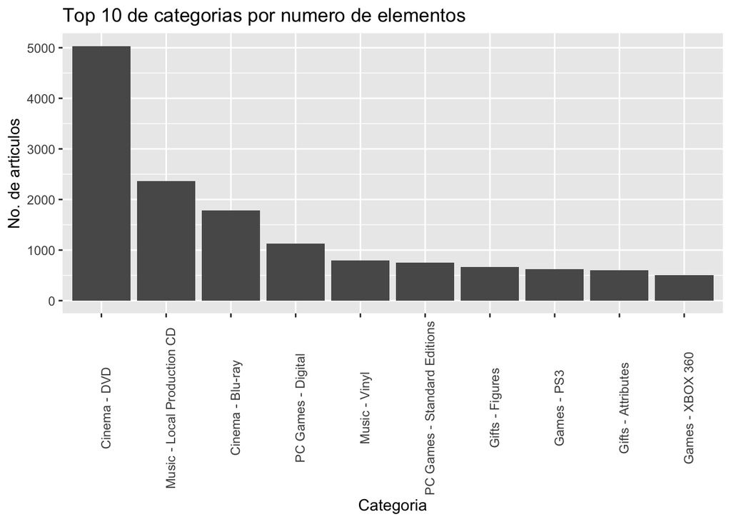

```r
ggplot(top10,aes(x = factor(item_category_id,top10$item_category_id[1:10]), y = conteo)) +
    geom_bar(stat = "identity")+
  theme(axis.text.x=element_text(angle=90))+
  ggtitle('Top 10 de categorias por numero de elementos')+
  xlab('Categoria')+
  ylab('No. de articulos')+
  scale_x_discrete(labels=top10$item_category_name)
```

```r
bottom10<-productos_por_categoria%>%
  top_n(-10)
```

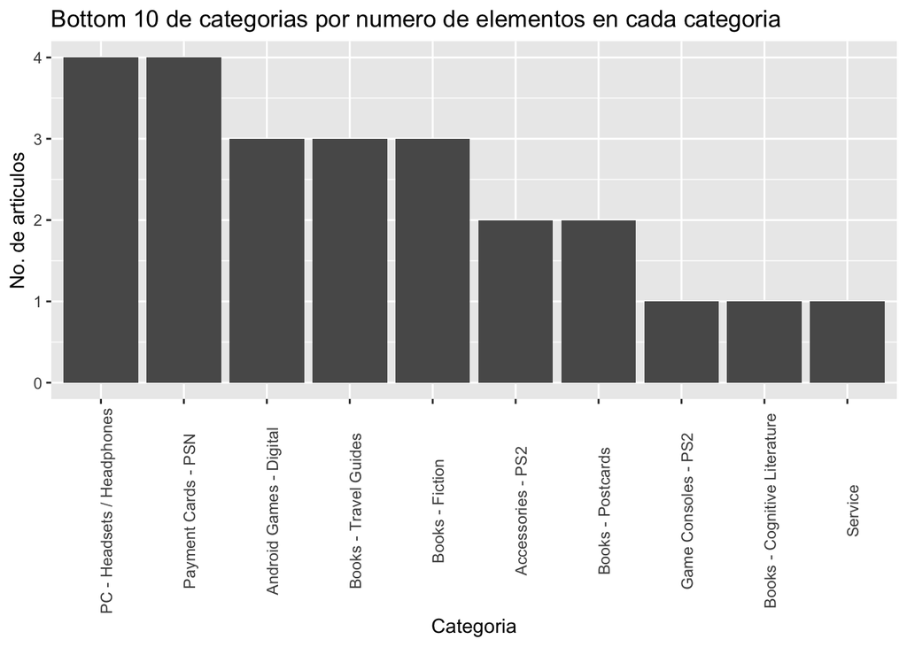

```r
ggplot(bottom10,aes(x = factor(item_category_id,bottom10$item_category_id[1:10]), y = conteo))+
    geom_bar(stat = "identity")+
  theme(axis.text.x=element_text(angle=90))+
  ggtitle('Bottom 10 de categorias por numero de elementos en cada categoria')+
  xlab('Categoria')+
  ylab('No. de articulos')+
  scale_x_discrete(labels=bottom10$item_category_name)
```

### Catalogo de tiendas

Hechamos un vistazo a los datos.

```r
glimpse(shops)
```

```
## Observations: 60
## Variables: 2
## $ shop_name <chr> "! Yakutsk Ordzhonikidze, 56 fran", "! Yakutsk Shopp...
## $ shop_id   <int> 0, 1, 2, 3, 4, 5, 6, 7, 8, 9, 10, 11, 12, 13, 14, 15...
```

Verificamos que el catálogo tenga las 60 tiendas que se describen en los datos.

```r
nrow(shops %>% select(shop_name) %>% unique())
```

```
## [1] 60
```

### Datos de entrenamiento

Hechamos un vistazo a los datos de entrenamiento.

```r
glimpse(train)
```

```
## Observations: 2,935,849
## Variables: 6
## $ date           <chr> "02.01.2013", "03.01.2013", "05.01.2013", "06.0...
## $ date_block_num <int> 0, 0, 0, 0, 0, 0, 0, 0, 0, 0, 0, 0, 0, 0, 0, 0,...
## $ shop_id        <int> 59, 25, 25, 25, 25, 25, 25, 25, 25, 25, 25, 25,...
## $ item_id        <int> 22154, 2552, 2552, 2554, 2555, 2564, 2565, 2572...
## $ item_price     <dbl> 999.00, 899.00, 899.00, 1709.05, 1099.00, 349.0...
## $ item_cnt_day   <dbl> 1, 1, -1, 1, 1, 1, 1, 1, 1, 3, 2, 1, 1, 2, 1, 2...
```

Vemos que algunas varaibles no están siendo reconocidas con el tipo correcto y faltan los nombres de los artículos, de las tiendas y de las categorías. Además, se requiere un identificador único para la dupla (tienda, artículo).

Primero generamos el identificador de la dupla. Este será almacenado en la variable ID.

```r
# Posibles combinaciones (tienda,art.)
duplas<-list(shop_id=unique(shops$shop_id),
             item_id=unique(datos_items$item_id))%>%
  expand.grid

# Se agrega el identificador.
duplas<-duplas%>%
  mutate(ID=1:nrow(duplas))%>%
  select(ID,everything())
```

Ahora, hacemos el left join de los datos de entrenamiento con el catálogo de artículos y con el de tiendas. Análogamente hacemos un left join con el ID de la dupla (tienda,artículo)

```r
# Se unen las distintas tablas
datos_train<-left_join(train,datos_items,by='item_id')%>%
  left_join(shops,by='shop_id')%>%
  left_join(duplas,by=c('item_id','shop_id'))

# Se vuelve a leer el tipo de cada dato.
readr::type_convert(datos_train)
```

```
## # A tibble: 2,935,849 x 11
##    date  date_block_num shop_id item_id item_price item_cnt_day item_name
##    <chr>          <int>   <int>   <int>      <dbl>        <dbl> <chr>
##  1 02.0~              0      59   22154       999             1 Scene 20~
##  2 03.0~              0      25    2552       899             1 DEEP PUR~
##  3 05.0~              0      25    2552       899            -1 DEEP PUR~
##  4 06.0~              0      25    2554      1709.            1 DEEP PUR~
##  5 15.0~              0      25    2555      1099             1 DEEP PUR~
##  6 10.0~              0      25    2564       349             1 DEEP PUR~
##  7 02.0~              0      25    2565       549             1 DEEP PUR~
##  8 04.0~              0      25    2572       239             1 DEFTONES~
##  9 11.0~              0      25    2572       299             1 DEFTONES~
## 10 03.0~              0      25    2573       299             3 DEL REY ~
## # ... with 2,935,839 more rows, and 4 more variables:
## #   item_category_id <int>, item_category_name <chr>, shop_name <chr>,
## #   ID <int>
```

Veamos cuantas duplas distintas tenemos en el set de entrenamiento.

```r
length(unique(datos_train$ID))
```

```
## [1] 424124
```

Se tienen 424,124 duplas en el set de entrenamiento de las 1,330,200 posibles.

# Preparación de los datos

## Selección de los datos

Hasta el momento, se seleccionan todas las variables disponibles. Cabe destacar que las variables de nombre de artículo, nombre de categoría y nombre de tienda se conservan con fines de interpretabilidad y para el análisis exploratorio, pero no se utilizarán en el modelado de los datos.

## Limpieza de datos

### Tipo de variables

Hechamos un vistazo a la base de datos obtenida del proceso de exploración.

```r
glimpse(datos_train)
```

```
## Observations: 2,935,849
## Variables: 11
## $ date               <chr> "02.01.2013", "03.01.2013", "05.01.2013", "...
## $ date_block_num     <int> 0, 0, 0, 0, 0, 0, 0, 0, 0, 0, 0, 0, 0, 0, 0...
## $ shop_id            <int> 59, 25, 25, 25, 25, 25, 25, 25, 25, 25, 25,...
## $ item_id            <int> 22154, 2552, 2552, 2554, 2555, 2564, 2565, ...
## $ item_price         <dbl> 999.00, 899.00, 899.00, 1709.05, 1099.00, 3...
## $ item_cnt_day       <dbl> 1, 1, -1, 1, 1, 1, 1, 1, 1, 3, 2, 1, 1, 2, ...
## $ item_name          <chr> "Scene 2012 (BD)", "DEEP PURPLE The House O...
## $ item_category_id   <int> 37, 58, 58, 58, 56, 59, 56, 55, 55, 55, 55,...
## $ item_category_name <chr> "Cinema - Blu-ray", "Music - Vinyl", "Music...
## $ shop_name          <chr> "Yaroslavl shopping center &quot;Altair&quo...
## $ ID                 <int> 1329300, 153146, 153146, 153266, 153326, 15...
```

La variable *date* no es reconocida como fecha y la variable *tiem_cnt_day* no es reconocida como entero. Se hacen estos cambios.

```r
# Se cambia la variable date a formato fechay la variable item_cnt_day a formato entero
datos_train<-datos_train%>%
  mutate(date=as.Date(date,format="%d.%m.%Y"),
         item_cnt_day=as.integer(item_cnt_day))%>%
  select(date,everything())
```

### Datos faltantes

Checamos si existen datos faltantes en el set de entrenamiento.

```r
# Summary para detectar presencia de NA's
summary(datos_train)
```

```
##       date            date_block_num     shop_id      item_id
##  Min.   :2013-01-01   Min.   : 0.00   Min.   : 0   Min.   :    0
##  1st Qu.:2013-08-01   1st Qu.: 7.00   1st Qu.:22   1st Qu.: 4476
##  Median :2014-03-04   Median :14.00   Median :31   Median : 9343
##  Mean   :2014-04-03   Mean   :14.57   Mean   :33   Mean   :10197
##  3rd Qu.:2014-12-05   3rd Qu.:23.00   3rd Qu.:47   3rd Qu.:15684
##  Max.   :2015-10-31   Max.   :33.00   Max.   :59   Max.   :22169
##    item_price        item_cnt_day       item_name         item_category_id
##  Min.   :    -1.0   Min.   : -22.000   Length:2935849     Min.   : 0
##  1st Qu.:   249.0   1st Qu.:   1.000   Class :character   1st Qu.:28
##  Median :   399.0   Median :   1.000   Mode  :character   Median :40
##  Mean   :   890.9   Mean   :   1.243                      Mean   :40
##  3rd Qu.:   999.0   3rd Qu.:   1.000                      3rd Qu.:55
##  Max.   :307980.0   Max.   :2169.000                      Max.   :83
##  item_category_name  shop_name               ID
##  Length:2935849     Length:2935849     Min.   :     55
##  Class :character   Class :character   1st Qu.: 268563
##  Mode  :character   Mode  :character   Median : 560612
##                                        Mean   : 611868
##                                        3rd Qu.: 941088
##                                        Max.   :1330166
```

No se tienen valores faltantes en el set de entrenamiento.

### Valores únicos por variable.

Se verifican los valores únicos por variable para ver si existen o bservaciones con errores o si vale la pena categorizar alguna variable.

Para las variables *date*, *date_block_num*, *shop_id*, *item_id*, *item_name*,*item_category_id*, *item_category_name*, *shop_name* y *ID* no es necesario checar los valores únicos ya se son identificadores de fecha, tienda, categoría o artículo.

Las variables que sí se deben revisar son *item_price* y *item_cnt_day*.

#### Precio por artículo

```r
length(unique(datos_train$item_price))
```

```
## [1] 19993
```

Para la variable *item_price* se tienen 19,993 precios únicos. Esto no es sorpresa ya que la variable es de tipo double. Veamos un summary de esta variable para poder decidir sobre su distribución y posible categorización.

```r
summary(datos_train$item_price)
```

```
##     Min.  1st Qu.   Median     Mean  3rd Qu.     Max.
##     -1.0    249.0    399.0    890.9    999.0 307980.0
```

En primer lugar, se puede notar que existen precios negativos, lo cual no es factible. En segundo lugar la diferencia entre el tercer cuantil y el máximo es muy grande, esto es señal de un dato atípico.

Veamos los 20 valores más grandes del precio de los artículos.

```r
head(sort(datos_train$item_price,decreasing = TRUE),20)
```

```
##  [1] 307980  59200  50999  49782  42990  42990  42990  42990  42000  41990
## [11]  41990  41990  40991  40900  37991  37991  36990  36990  36990  36990
```

Efectivamente se trata de un valor atípico. Veamos de qué producto se trata.

```r
datos_train$item_name[which(datos_train$item_price==307980)]
```

```
## [1] "Radmin 3 - 522 persons."
```

Investigando en 1C y, asumiendo que el precio está en dólares, se llegó a la conclusión de que se escribó mal el precio de este artículo y sería razonable pensar que el verdadero precio es de $3,079.80 dólares. Por lo tanto, se sustitye dico valor.

```r
datos_train$item_price[which(datos_train$item_price==307980)]<-3079.80
```

En cuanto a los precios negativos, veamos cuantos son.

```r
length(which(datos_train$item_price<0))
```

```
## [1] 1
```

```r
# extraemos los items devueltos
item_id_pneg<-datos_train%>%
  filter(item_price<0)%>%
  select(item_id)%>%
  unique()%>%
  as.numeric

# extraemos la fecha de devolucion
date_pneg<-datos_train%>%
  filter(item_price<0)%>%
  select(date)%>%
  unique()

# Extraemso el precio promedio del objeto en la misma fecha
items_ppos<-datos_train%>%
  filter(item_id==item_id_pneg)%>%
  filter(date==date_pneg)%>%
  filter(item_price!=-1)%>%
  select(date, item_name, item_price)

datatable(items_ppos)
```

|  | date | item_name | item_price |
| --- | --- | --- | --- |
| 1 | 2013-05-15 | DmC Devil May Cry [PS3, Russian subtitles] | 1249.5 |
| 2 | 2013-05-15 | DmC Devil May Cry [PS3, Russian subtitles] | 1249.5 |
| 3 | 2013-05-15 | DmC Devil May Cry [PS3, Russian subtitles] | 1249 |

```r
summary(datos_train$item_price)
```

```
##    Min. 1st Qu.  Median    Mean 3rd Qu.    Max.
##    -1.0   249.0   399.0   890.8   999.0 59200.0
```

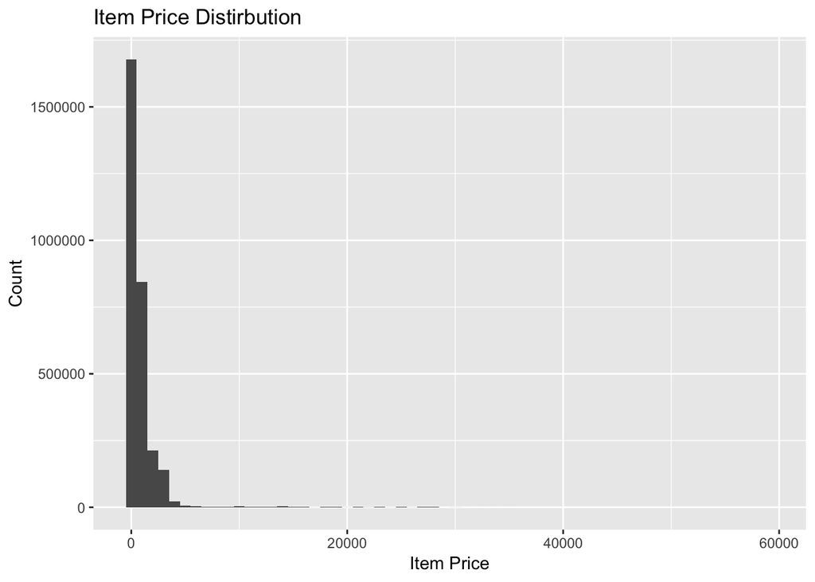

```r
ggplot(datos_train,aes(item_price))+
  geom_histogram(binwidth = 1000)+
  ggtitle('Item Price Distirbution')+
  xlab('Item Price')+
  ylab('Count')
```

Todavía existe una gran diferencia entre el tercer cuantil y el valor máximo del precio. Sin embargo, dado aue la tarea es predecir el número de articulos vendido cada mes de cada tipo en cada tienda, por el momento, no se realiza ninguna estrategia de categorización del precio. De ser necesario, se realizará en la parte de ingeniería de características.

#### Número de unidades vendidas/devueltas.

Verificamos los valores únicos para la variable *item_cnt_day*.

```r
sort(unique(datos_train$item_cnt_day),decreasing = TRUE)
```

```
##   [1] 2169 1000  669  637  624  539  533  512  508  504  502  501  500  480
##  [15]  412  405  401  343  325  313  300  299  288  264  255  251  242  240
##  [29]  231  230  222  217  207  205  200  195  194  187  179  171  168  167
##  [43]  164  163  161  157  156  154  153  151  150  149  148  147  146  145
##  [57]  142  140  139  138  135  134  133  132  131  130  129  128  127  126
##  [71]  124  121  118  117  116  115  114  113  112  111  110  109  108  107
##  [85]  106  105  104  103  102  101  100   99   98   97   96   95   93   92
##  [99]   91   90   89   88   87   86   85   84   83   82   81   80   79   78
## [113]   77   76   75   74   73   72   71   70   69   68   67   66   65   64
## [127]   63   62   61   60   59   58   57   56   55   54   53   52   51   50
## [141]   49   48   47   46   45   44   43   42   41   40   39   38   37   36
## [155]   35   34   33   32   31   30   29   28   27   26   25   24   23   22
## [169]   21   20   19   18   17   16   15   14   13   12   11   10    9    8
## [183]    7    6    5    4    3    2    1   -1   -2   -3   -4   -5   -6   -9
## [197]  -16  -22
```

El número de unidades vendidas por artículo va desde 1 hasta 2169. El número de unidades devueltas por artículo va desde 1 hasta 22. No parece haber nada incorrecto en esta variable.

Veamos que artículos fueron los más vendidos.

```r
cnt_day_mayores<-sort(unique(datos_train$item_cnt_day),decreasing = TRUE)[1:10]

datos_train$item_name[match(cnt_day_mayores,datos_train$item_cnt_day)]
```

```
##  [1] "Delivery to the point of delivery (Boxberry)"
##  [2] "Corporate package undershirt 1C Interest white (34 * 42) 45 microns"
##  [3] "Ticket &quot;IgroMir 2015&quot; - October 3, 2015 (website) [Digital version]"
##  [4] "Ticket &quot;IgroMir 2015&quot; - October 3, 2015 (website) UPR [Digital version]"
##  [5] "Grand Theft Auto V [PC, Russian subtitles]"
##  [6] "Delivery to the point of delivery (Boxberry)"
##  [7] "Ticket &quot;IgroMir 2015&quot; - October 3, 2015 (website) UPR [Digital version]"
##  [8] "Ticket &quot;IgroMir 2014&quot; (for one day (separately - October 4, 5, 2014))"
##  [9] "Middle-earth: Shadow of Mordor [PC, Digital Edition]"
## [10] "Ticket &quot;IgroMir 2015&quot; - October 3, 2015 (website) [Digital version]"
```